# useR! 2019 Survey Stats

## Registered participants

useR! 2019 received 1,192 registered participants.

### by gender

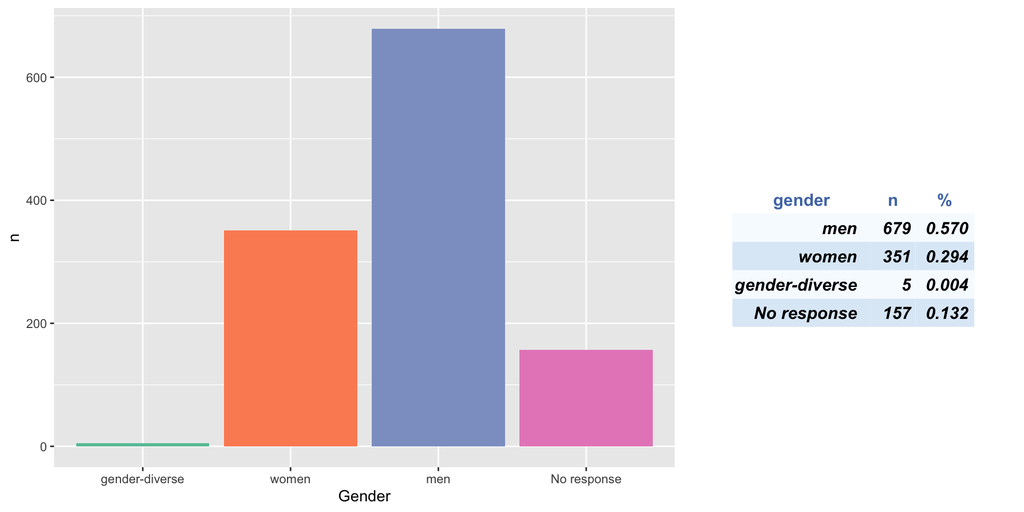

## Survey respondents

The response rate was lower than usual this year because we were not able to advertise the survey by email.

### by age

Over 55 are grouped together.

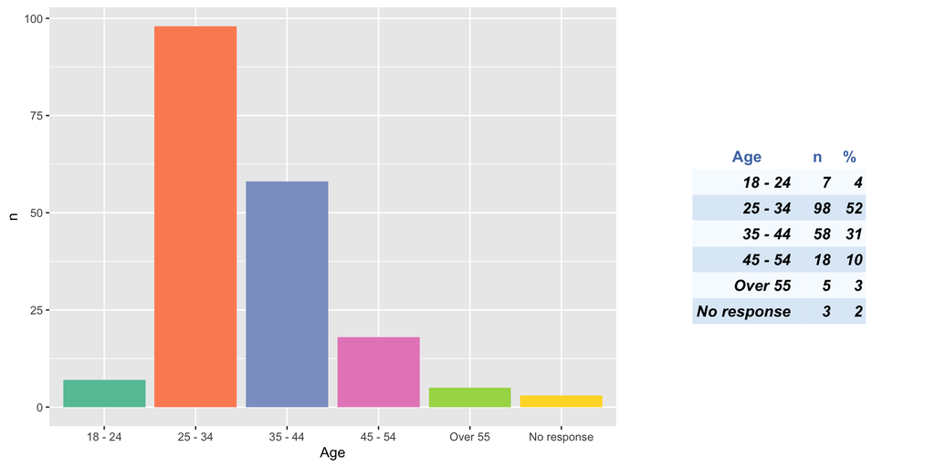

### by country

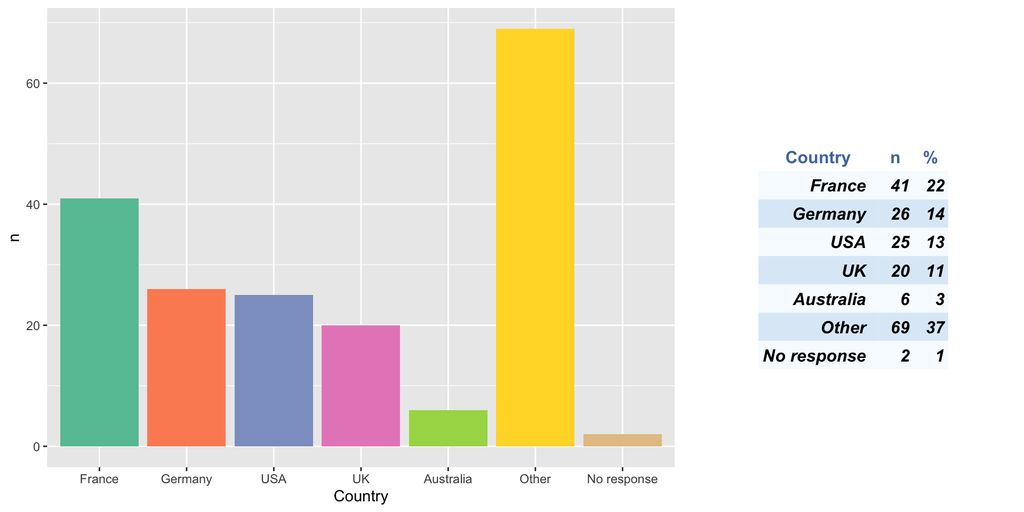

### by ethnicity This question is omitted from the survey this year.

### by gender

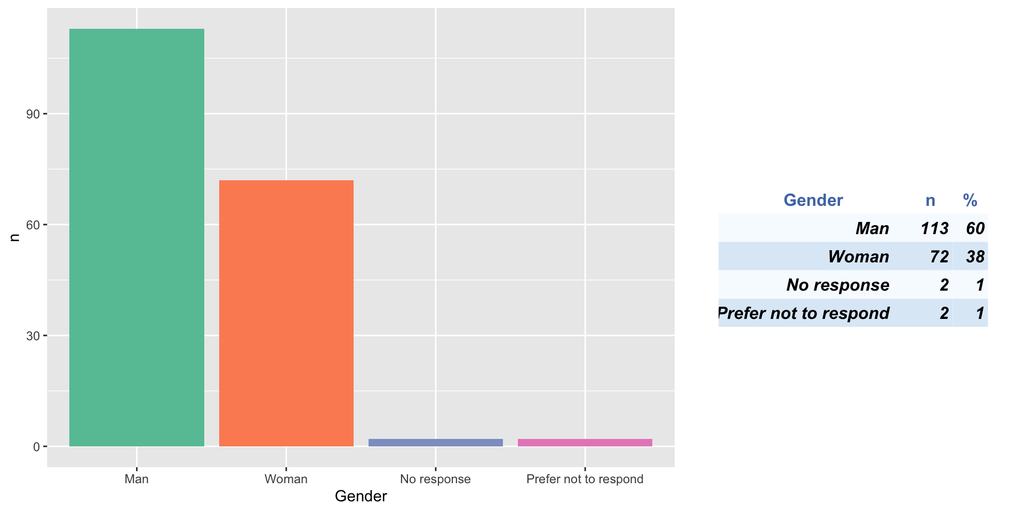

### by LGBT+ status

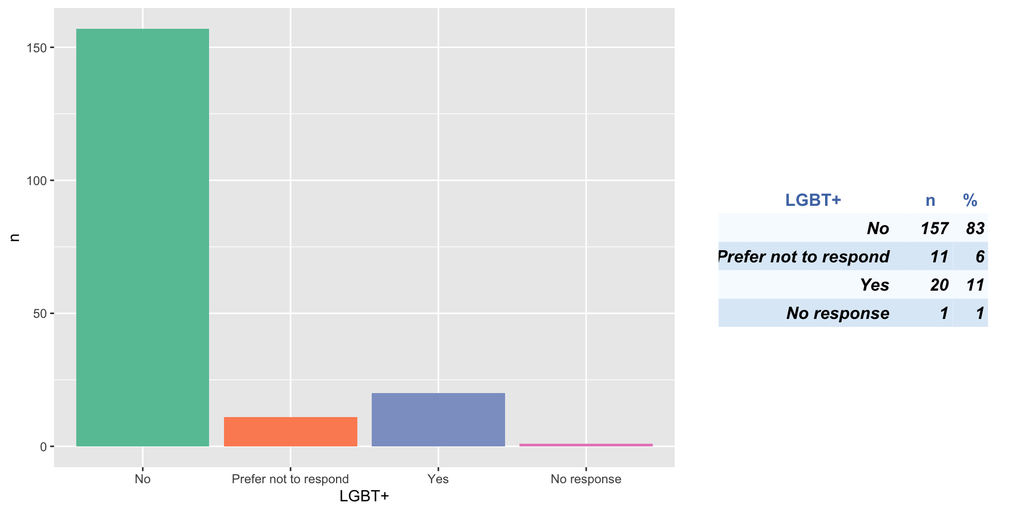

### by disability status

Other disabilities/impairments included a learning disability, a mobility impairment, and chronic pain. Some individuals specified more than one disability/impairment.

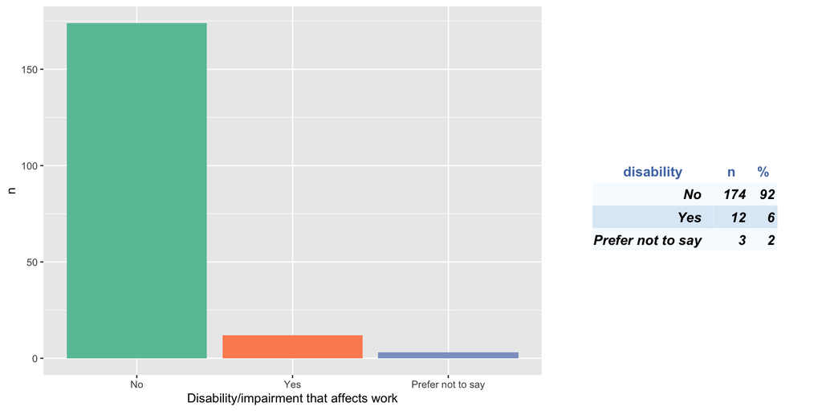

### by education

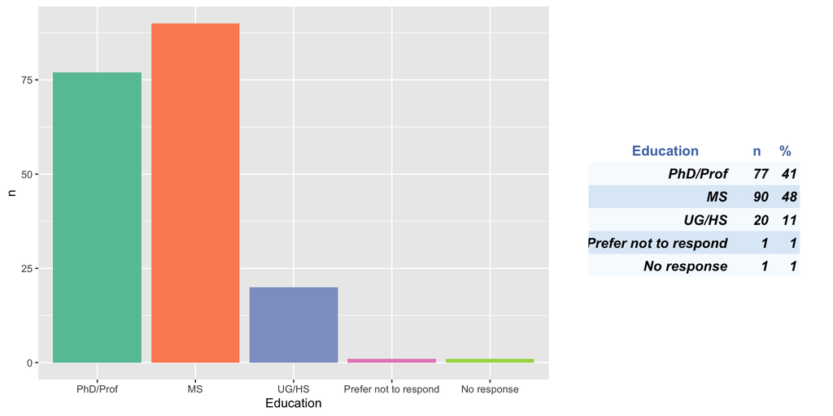

### by sector of employment

Here salaried students are categorised as employed in academia. Other includes retired, casually employed and unemployed.

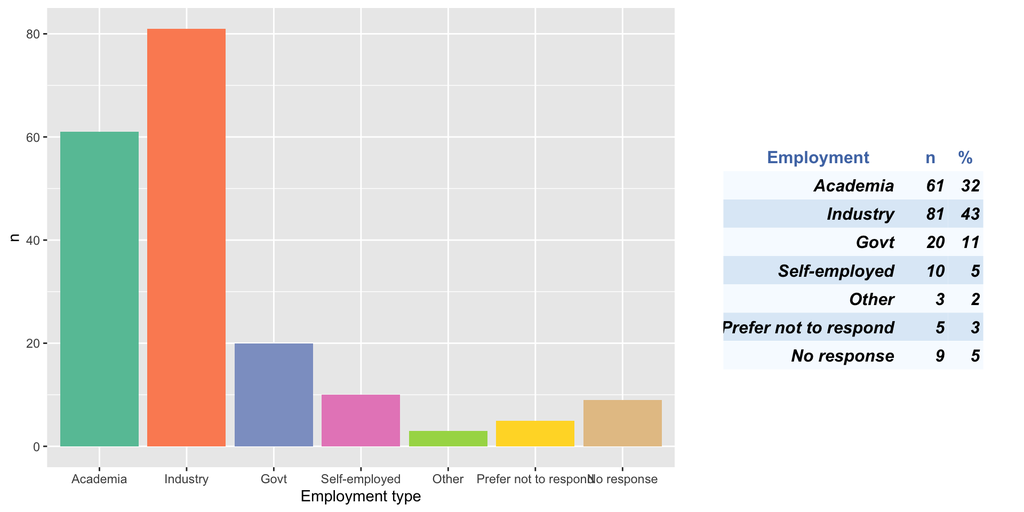

### by employment status

Employment here refers to any paid employment.

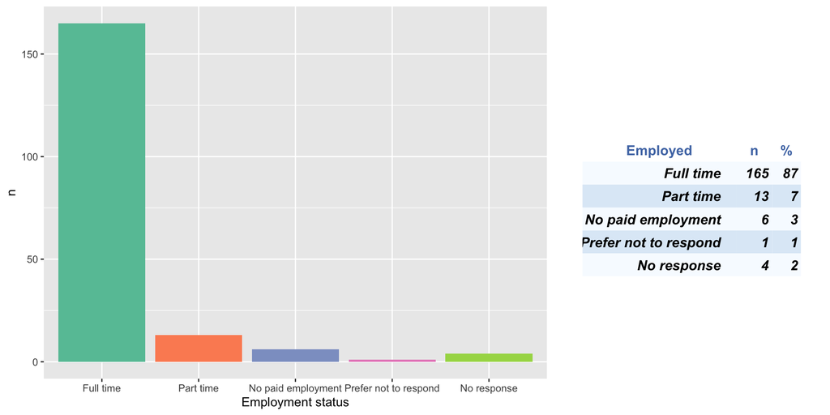

### by caregiver status

Here a caregiver is anyone that has dependents.

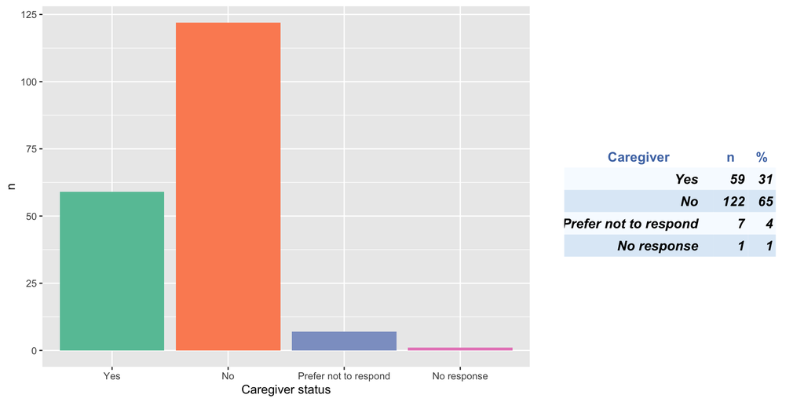

### by experience in using R

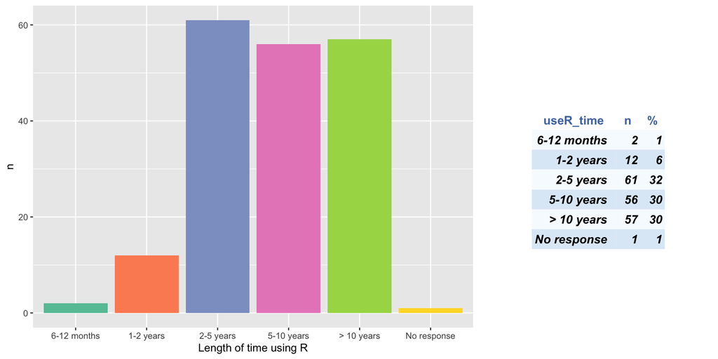

### by use of R for work

Here “fundamental” is used when the respondent said they used R for work; “supplemental” is used when the respondent said they use R when they can find an excuse to, but it’s not a requirement of their role.

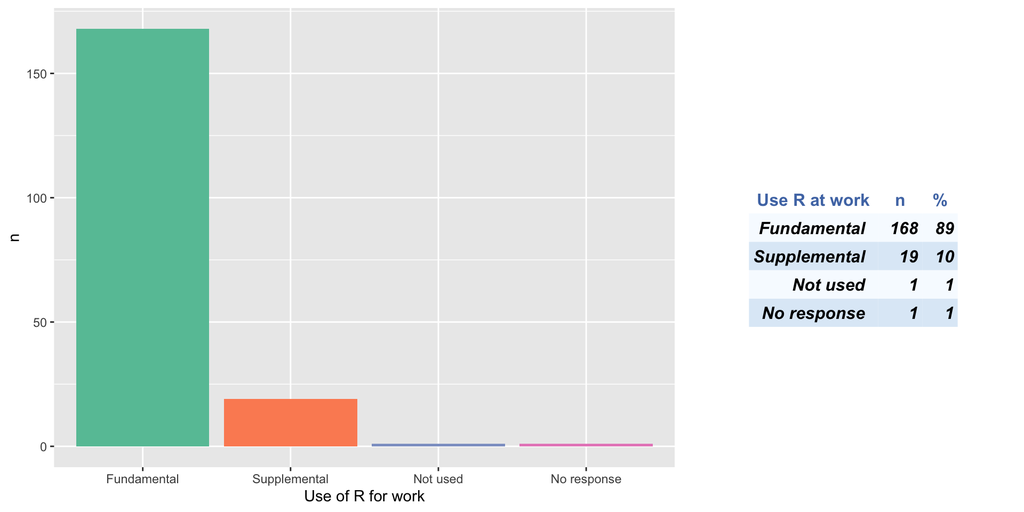

## Presentations

There are 189 participated in presentation activities.

### by age

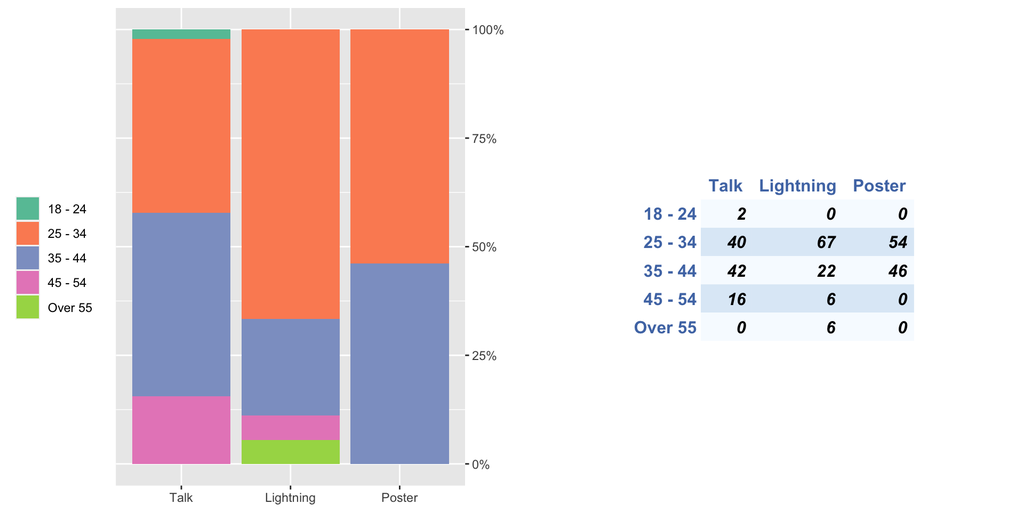

### by ethnicity

This question is omitted from the survey this year.

### by gender

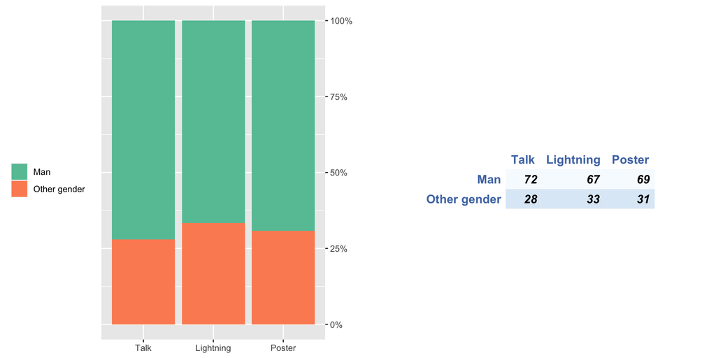

### by education

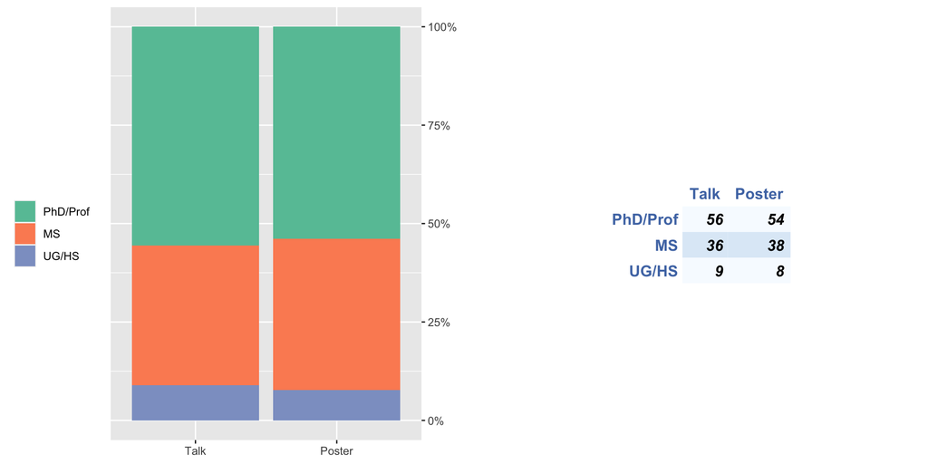

### by sector of employment

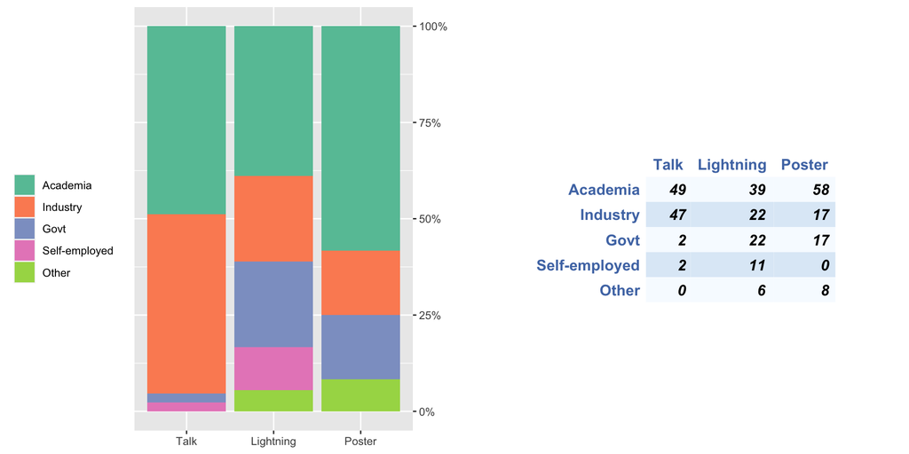

### by experience in using R

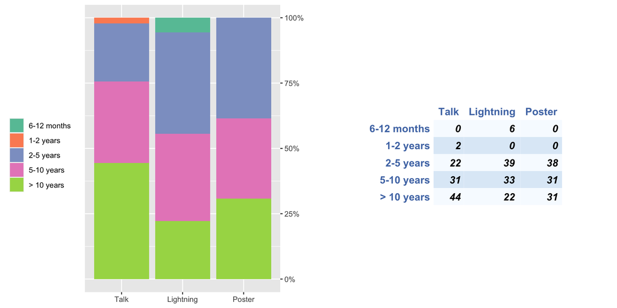

### by use of R for work

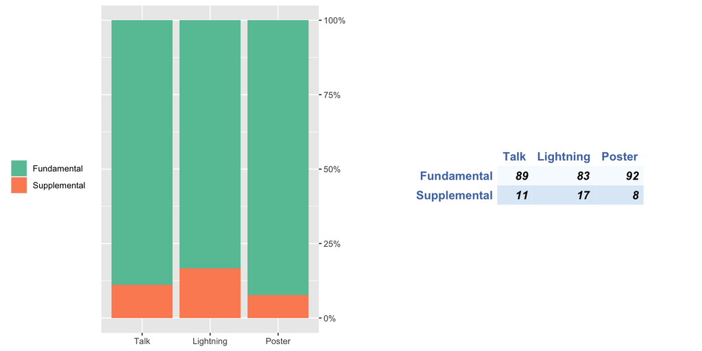

## Special Session

In total 30 people presentetd a speccial session.

### by age

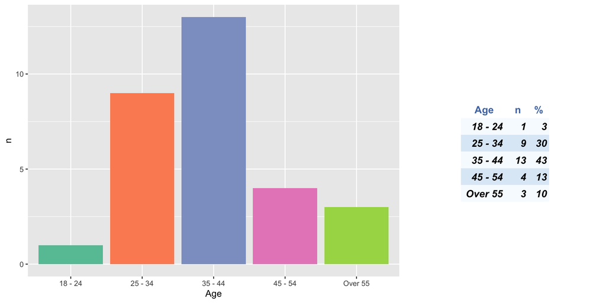

### by gender

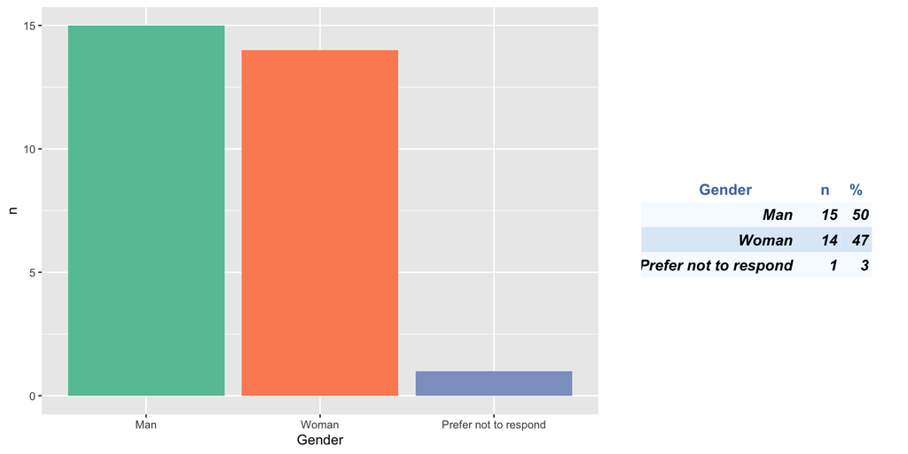

### by education

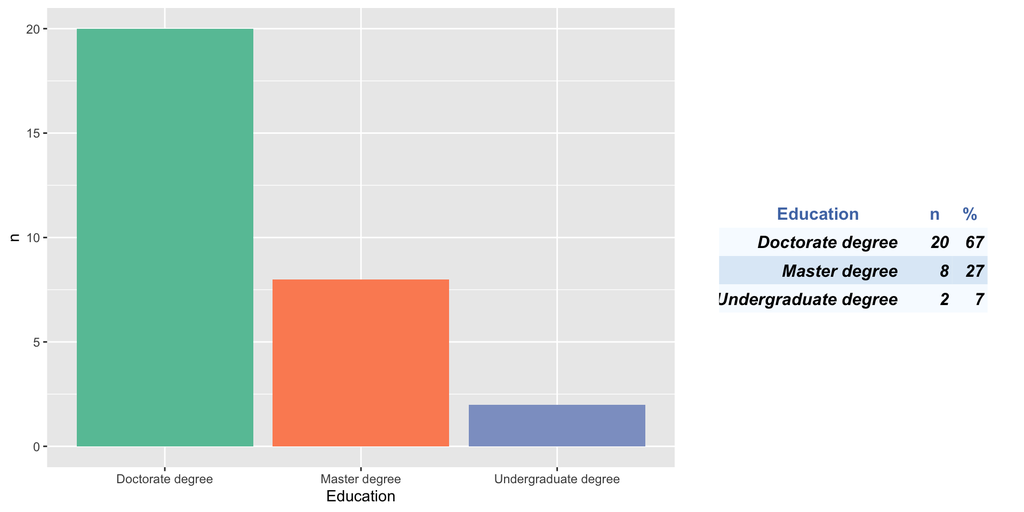

### by employment

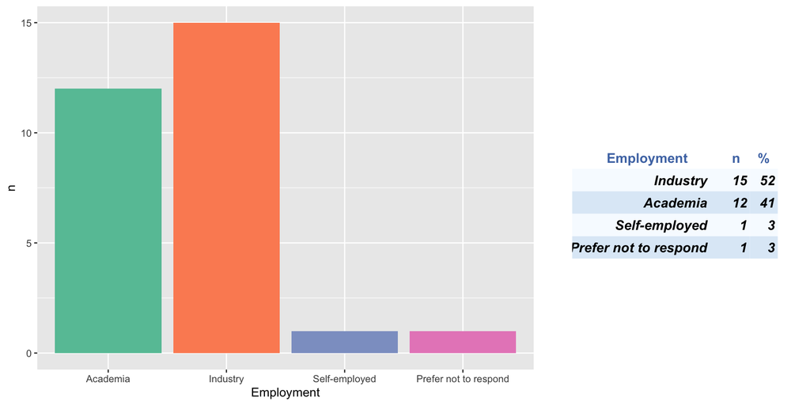

### by experience in using R

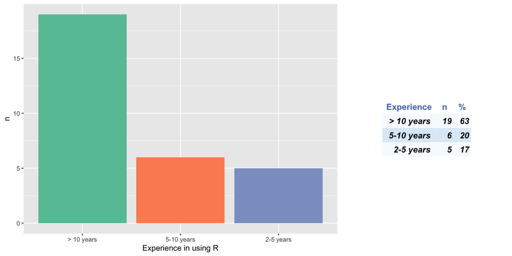

This following section summarises the overall satisfaction with useR! 2019 conference.

## Satisfaction with the Conference

### Satisfaction following aspects of the useR! program

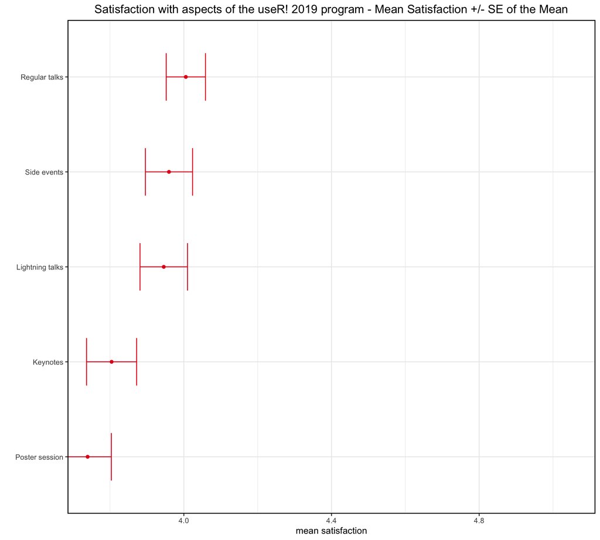

### Satisfaction following aspects of the useR! organization

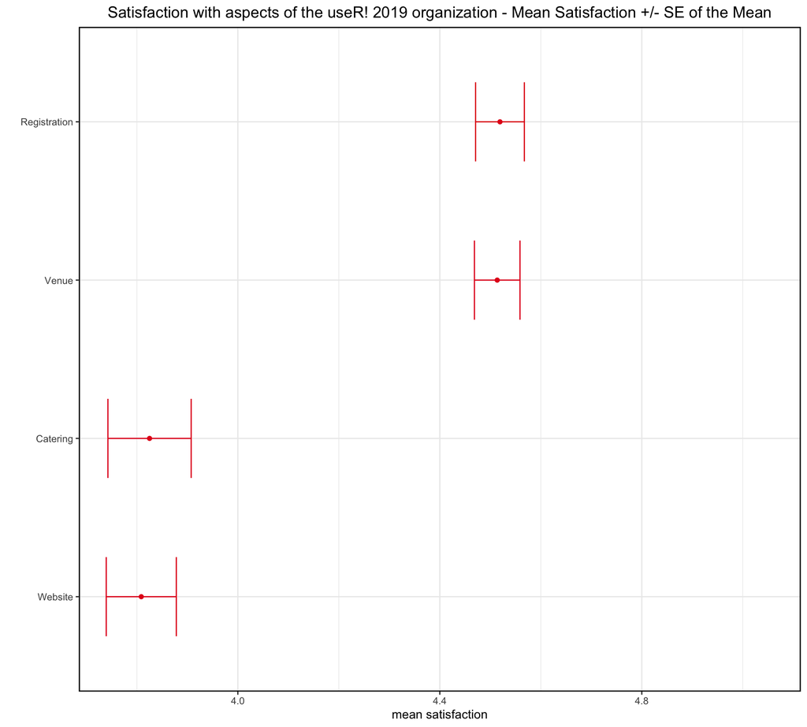